# Covid-19 Report

Ömür Özkir

April 10, 2020

# The dataset

The dataset used is available at [Github](https://ramikrispin.github.io/coronavirus/) under https://ramikrispin.github.io/coronavirus/ and updated daily (but might be delayed by up to a day).

The source additionally provides the data as csv file and also offers a comprehensive dashboard based on this dataset.

# The Last 24 Hours

## Worldwide Confirmed Cases

| latest_report | confirmed_cases |
| --- | --- |
| 2020-04-09 | 1595350 |

## Total cases by country

| Country.Region | type | total_cases |
| --- | --- | --- |
| US | confirmed | 461437 |
| Spain | confirmed | 153222 |
| Italy | confirmed | 143626 |
| France | confirmed | 118781 |
| Germany | confirmed | 118181 |
| China | confirmed | 82883 |
| China | recovered | 77679 |
| Iran | confirmed | 66220 |
| United Kingdom | confirmed | 65872 |
| Germany | recovered | 52407 |

## Confirmed New Cases

These numbers are only as good as the amount of testing done and should be taken with a grain of salt.

Also keep in mind that there is a significant delay between being infected and having the results of the test. Testing in most countries will only be done once symptoms appear and the test itself can also take a few days. The numbers basically reflect the state of a few days in the past (the exact number of days varies from country to country).

| country | confirmed |
| --- | --- |
| US | 32385 |
| Spain | 5002 |
| Germany | 4885 |
| France | 4822 |
| United Kingdom | 4398 |
| Italy | 4204 |
| Turkey | 4056 |
| Brazil | 1922 |
| Iran | 1634 |
| Belgium | 1580 |

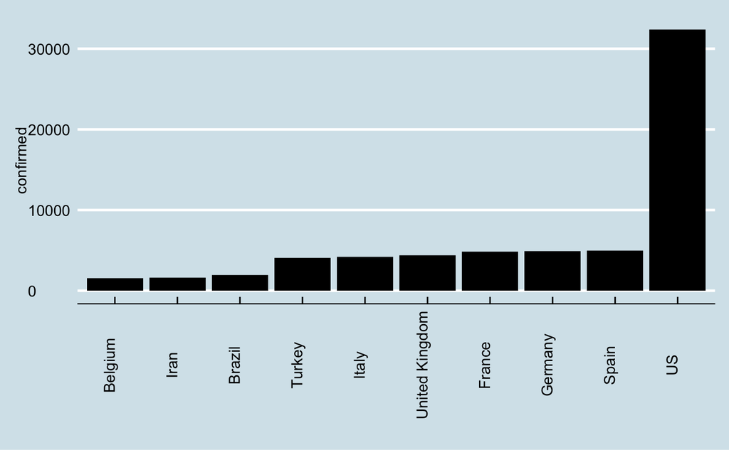

**April 8** The number of new cases is still rising in the US, to 32829 new cases. France saw a drop in new cases while Germany saw a slight increase in new cases.

**April 7**

The US is still leading the charts with a terrifying number of almost 30.000 new cases.

France has the second-highest number of new cases, with more than 11.000 new cases.

## New Deaths due to COVID-19

| country | death |
| --- | --- |
| US | 1783 |
| France | 1341 |
| United Kingdom | 882 |
| Spain | 655 |
| Italy | 610 |
| Belgium | 283 |
| Germany | 258 |
| Netherlands | 148 |
| Brazil | 131 |
| Iran | 117 |

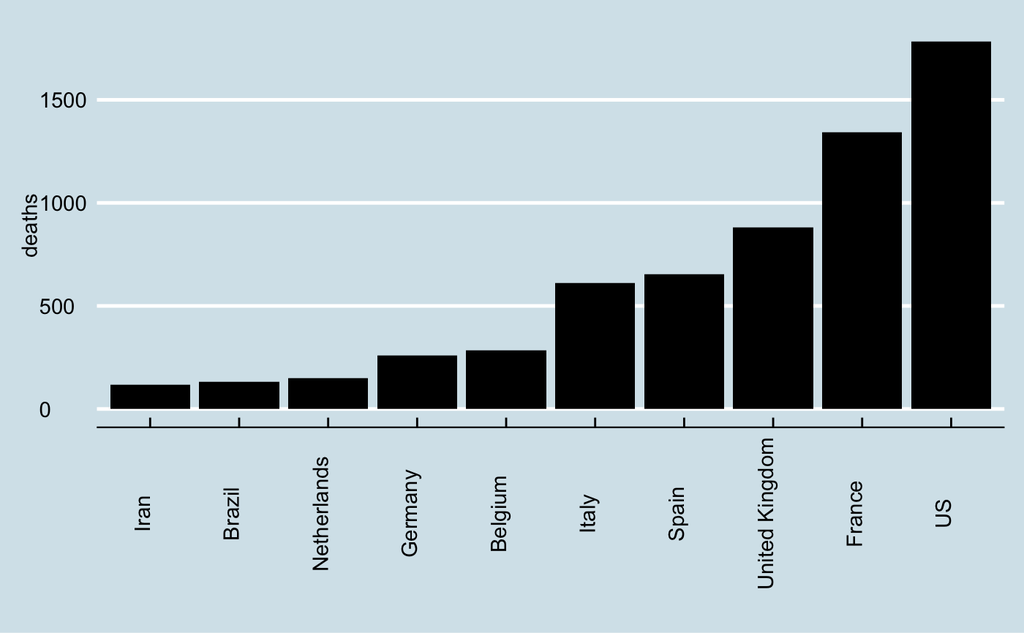

**April 8** The UK is experiencing a wave of new deaths (940 deaths today), while the US continues to have the most deaths caused by COVID-19 (1973 today).

**April 7**

France is experiencing a sad rise in deaths caused by the corona virus, 1417 today, only overshadowed by the deaths in the US, which lost 1939 people to the virus today.

## New Recovered Cases

| country | recovered |
| --- | --- |
| Germany | 6107 |
| Spain | 4144 |
| Iran | 2497 |
| Italy | 1979 |
| France | 1961 |
| US | 1851 |
| Canada | 1008 |
| Switzerland | 800 |
| Austria | 728 |
| Belgium | 483 |

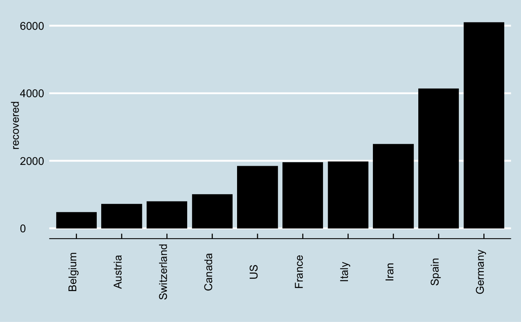

**April 8** The number of todays’ recovered cases in Germany rose to over 10000 and Spain also seems to slowly recover.

**April 7**

Germany could report 7381 recovered cases, the most world-wide.

# Trends

## Worldwide

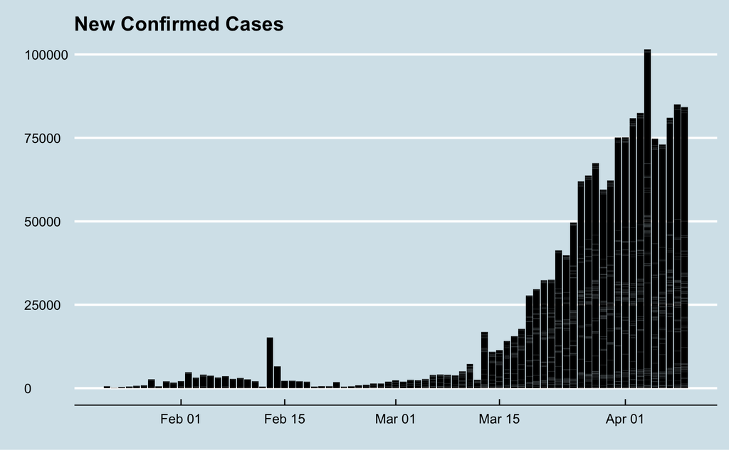

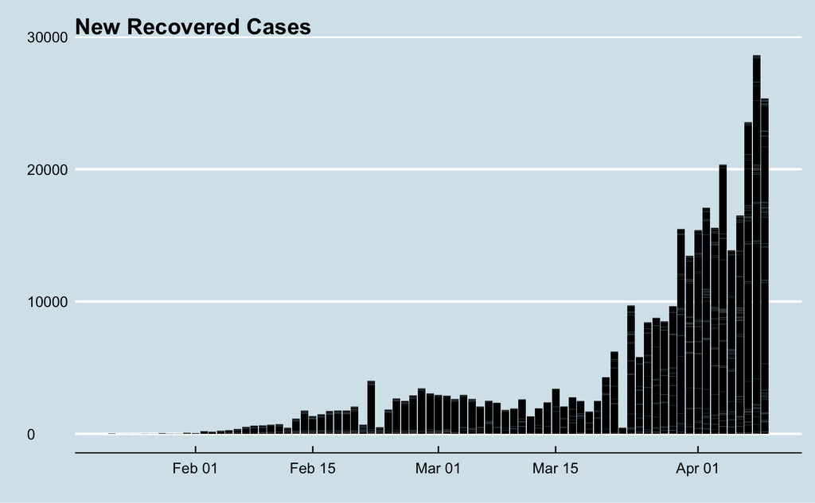

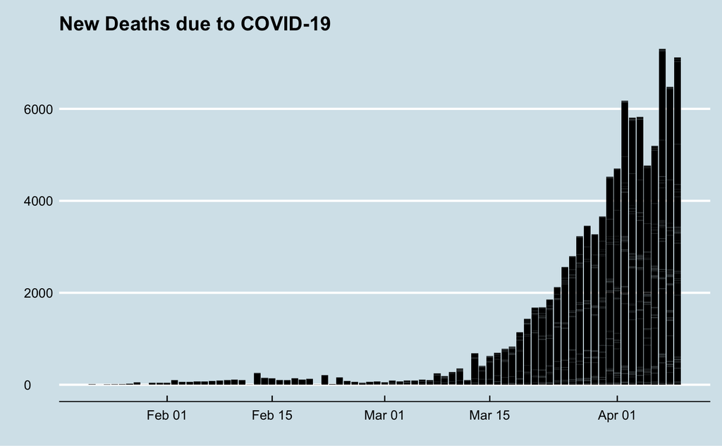

## Germany

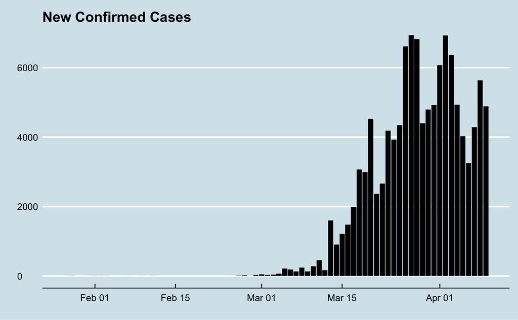

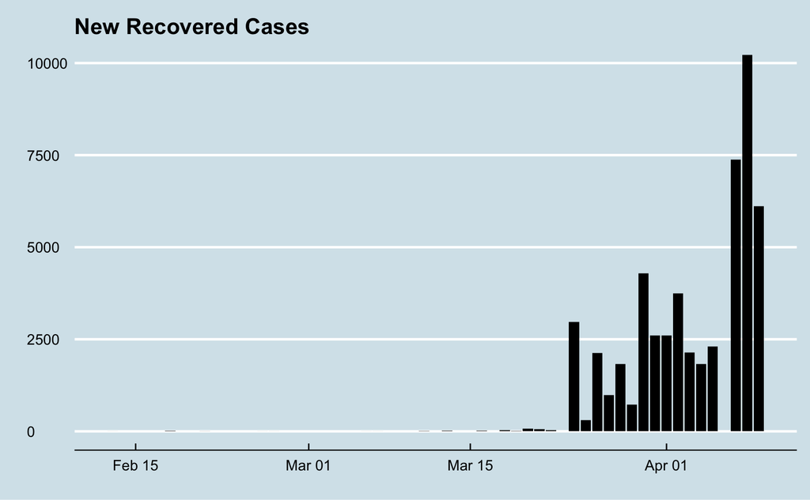

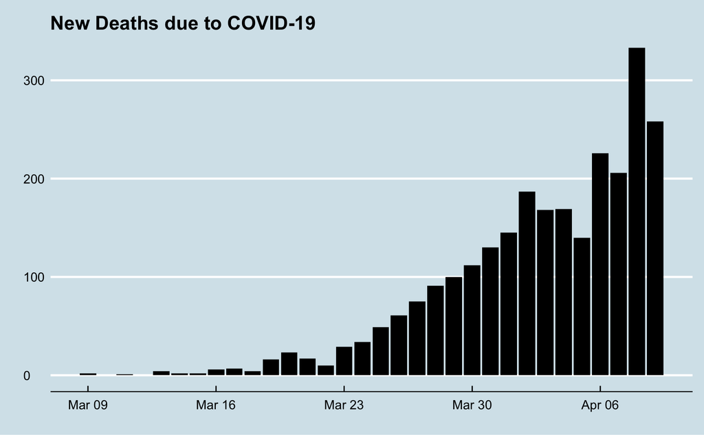

## France

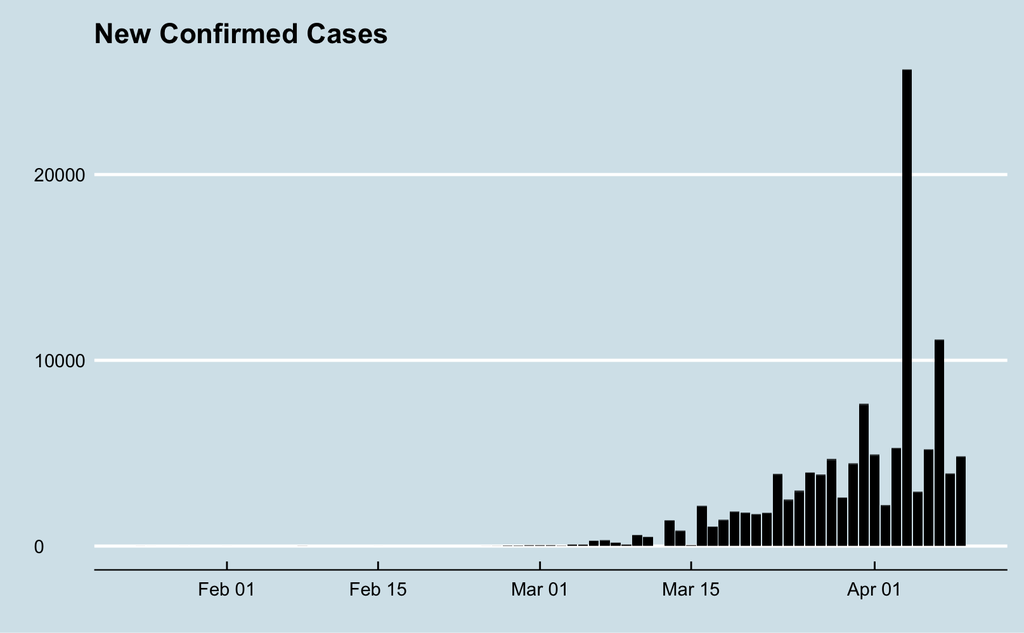

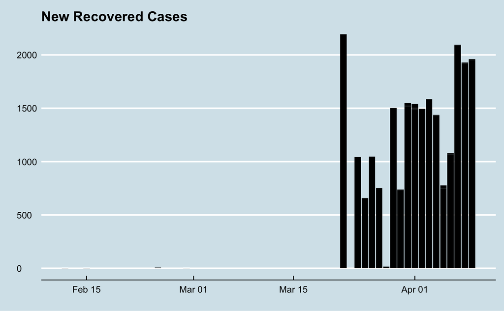

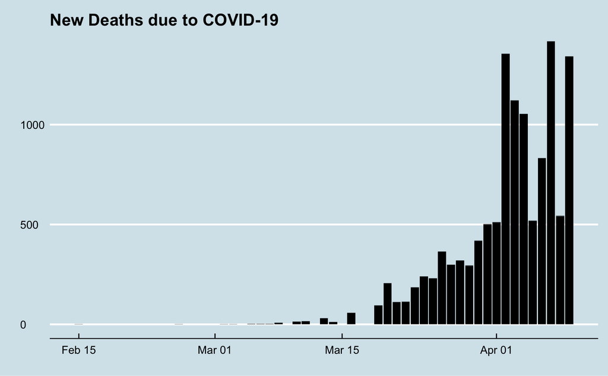

## Italy

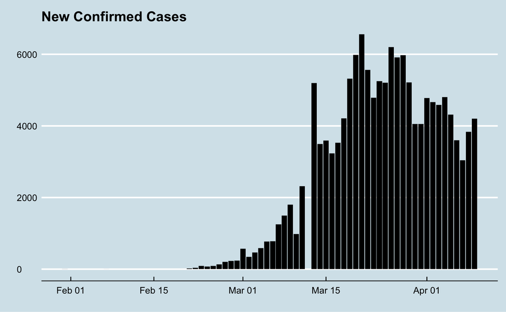

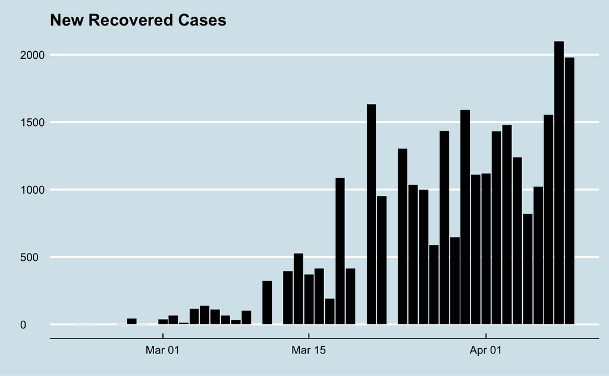

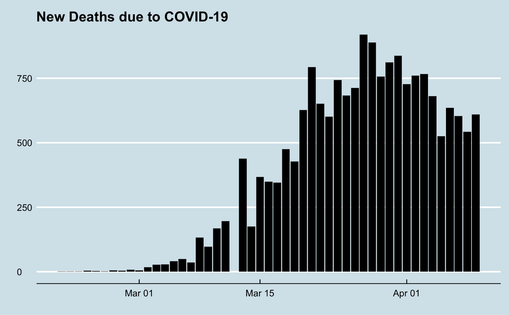